# Concrete Prediction Using Linear Model

Faisal Amir Maz

2022-12-18

```r
library(dplyr)
library(tidyverse)
# Exploratory Data Analysis
library(GGally)
# Modeling and Evaluation
library(randomForest)
library(yardstick)
library(lmtest)
# Model Interpretation
library(lime)
# Set theme for visualization
theme_set(theme_minimal())

options(scipen = 999)
```

# EDA

## Understanding Data

```r
concrete <- read.csv("data-train.csv")

head(concrete)
```

|  | id | cement | slag | flyash | water | super_plast | coarse_agg | fine_agg | age | strength |
| --- | --- | --- | --- | --- | --- | --- | --- | --- | --- | --- |
| 1 | S1 | 540.0 | 0.0 | 0 | 162 | 2.5 | 1040.0 | 676.0 | 28 | 79.99 |
| 2 | S2 | 540.0 | 0.0 | 0 | 162 | 2.5 | 1055.0 | 676.0 | 28 | 61.89 |
| 3 | S3 | 332.5 | 142.5 | 0 | 228 | 0.0 | 932.0 | 594.0 | 270 | 40.27 |
| 4 | S4 | 332.5 | 142.5 | 0 | 228 | 0.0 | 932.0 | 594.0 | 365 | 41.05 |
| 5 | S5 | 198.6 | 132.4 | 0 | 192 | 0.0 | 978.4 | 825.5 | 360 | 44.30 |
| 6 | S6 | 380.0 | 95.0 | 0 | 228 | 0.0 | 932.0 | 594.0 | 365 | 43.70 |

```r
glimpse(concrete)
```

```
## Rows: 825
## Columns: 10
## $ id          <chr> "S1", "S2", "S3", "S4", "S5", "S6", "S7", "S8", "S9", "S10…
## $ cement      <dbl> 540.0, 540.0, 332.5, 332.5, 198.6, 380.0, 380.0, 475.0, 19…
## $ slag        <dbl> 0.0, 0.0, 142.5, 142.5, 132.4, 95.0, 95.0, 0.0, 132.4, 132…
## $ flyash      <dbl> 0, 0, 0, 0, 0, 0, 0, 0, 0, 0, 0, 0, 0, 0, 0, 0, 0, 0, 0, 0…
## $ water       <dbl> 162, 162, 228, 228, 192, 228, 228, 228, 192, 192, 228, 228…
## $ super_plast <dbl> 2.5, 2.5, 0.0, 0.0, 0.0, 0.0, 0.0, 0.0, 0.0, 0.0, 0.0, 0.0…
## $ coarse_agg  <dbl> 1040.0, 1055.0, 932.0, 932.0, 978.4, 932.0, 932.0, 932.0, …
## $ fine_agg    <dbl> 676.0, 676.0, 594.0, 594.0, 825.5, 594.0, 594.0, 594.0, 82…
## $ age         <int> 28, 28, 270, 365, 360, 365, 28, 28, 90, 28, 28, 90, 90, 36…
## $ strength    <dbl> 79.99, 61.89, 40.27, 41.05, 44.30, 43.70, 36.45, 39.29, 38…
```

The data type seems OK. No need to change the data type. The “flyash” column looks like all zero in glimpse(). We need to see it further. The data contains 10 columns and 825 rows.

```r
anyNA(concrete)
```

```
## [1] FALSE
```

No NA values in dataset.

```r
sum(duplicated(concrete))
```

```
## [1] 0
```

There’s also no duplicated data.

```r
summary(concrete)
```

```
##       id                cement           slag            flyash
##  Length:825         Min.   :102.0   Min.   :  0.00   Min.   :  0.00
##  Class :character   1st Qu.:194.7   1st Qu.:  0.00   1st Qu.:  0.00
##  Mode  :character   Median :275.1   Median : 20.00   Median :  0.00
##                     Mean   :280.9   Mean   : 73.18   Mean   : 54.03
##                     3rd Qu.:350.0   3rd Qu.:141.30   3rd Qu.:118.20
##                     Max.   :540.0   Max.   :359.40   Max.   :200.10
##      water        super_plast       coarse_agg        fine_agg
##  Min.   :121.8   Min.   : 0.000   Min.   : 801.0   Min.   :594.0
##  1st Qu.:164.9   1st Qu.: 0.000   1st Qu.: 932.0   1st Qu.:734.0
##  Median :184.0   Median : 6.500   Median : 968.0   Median :780.1
##  Mean   :181.1   Mean   : 6.266   Mean   : 972.8   Mean   :775.6
##  3rd Qu.:192.0   3rd Qu.:10.100   3rd Qu.:1028.4   3rd Qu.:826.8
##  Max.   :247.0   Max.   :32.200   Max.   :1145.0   Max.   :992.6
##       age            strength
##  Min.   :  1.00   Min.   : 2.33
##  1st Qu.:  7.00   1st Qu.:23.64
##  Median : 28.00   Median :34.57
##  Mean   : 45.14   Mean   :35.79
##  3rd Qu.: 56.00   3rd Qu.:45.94
##  Max.   :365.00   Max.   :82.60
```

The “flyash” column is not all zero.

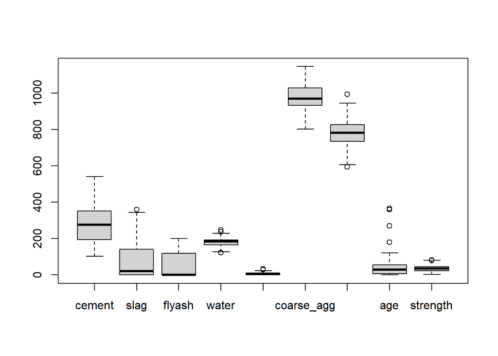

```r
concrete %>% select(-id) %>% boxplot()
```

The target variable contains outliers. The outliers seems not too far from the threshold line, so lets just left the outlier there for early development. Based on some literature, not every outliers harm the model. If the model not good enough we can try to delete the outliers on the future development.

## Inspection on Correlation between Columns

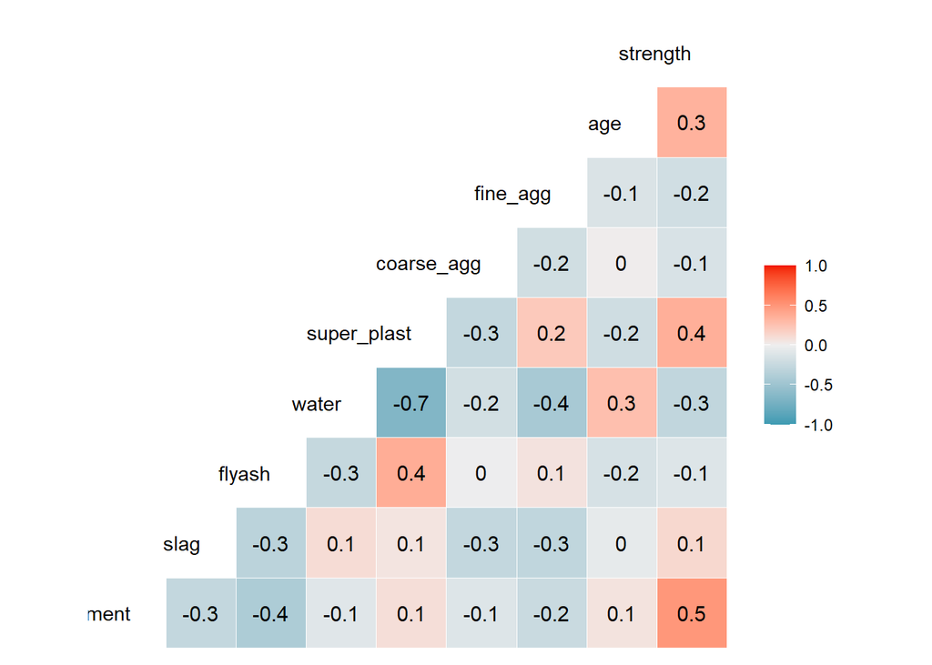

```r
library(GGally)
ggcorr(data = concrete, label = T, hjust = 1)
```

The highest correlation predictor column with the strength is “cement” column with correlation value 0.5. They are positively correlated. This is make sense because if we want to make a stronger concrete, we need more cement.

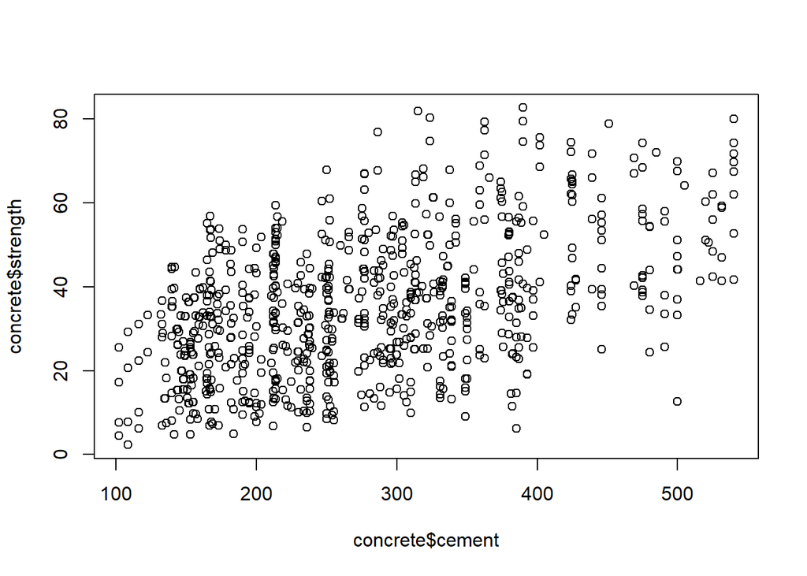

```r
plot(concrete$cement, concrete$strength)
```

## Cross-validation

We’ll make the proportion of training and testing 80:20. The process of deviding the data is done randomly. This is can be achieved by setting seed() value and using the sample() function.

```r
set.seed(123)
df_row <- nrow(concrete)

index <- sample(df_row, 0.8*df_row)

data_train <- concrete[ index, ]
data_test <- concrete[ -index, ]
```

```r
data_train <- data_train %>%
  select(-id)
head(data_train)
```

|  | cement | slag | flyash | water | super_plast | coarse_agg | fine_agg | age | strength |
| --- | --- | --- | --- | --- | --- | --- | --- | --- | --- |
| 415 | 424.0 | 22.0 | 132.0 | 178.0 | 8.5 | 822.0 | 750.0 | 7 | 39.00 |
| 463 | 228.0 | 342.1 | 0.0 | 185.7 | 0.0 | 955.8 | 674.3 | 28 | 39.70 |
| 179 | 190.3 | 0.0 | 125.2 | 161.9 | 9.9 | 1088.1 | 802.6 | 56 | 38.56 |
| 526 | 183.9 | 122.6 | 0.0 | 203.5 | 0.0 | 959.2 | 800.0 | 3 | 4.90 |
| 195 | 213.8 | 98.1 | 24.5 | 181.7 | 6.7 | 1066.0 | 785.5 | 3 | 13.18 |
| 818 | 321.4 | 0.0 | 127.9 | 182.5 | 11.5 | 870.1 | 779.7 | 28 | 37.27 |

# Model Fitting

The models that are being used: - linear model - Random forest - Support vector machine regression

## Linear Model

```r
model_linear <- lm(strength ~ . , data = data_train)

summary(model_linear)
```

```
##
## Call:
## lm(formula = strength ~ ., data = data_train)
##
## Residuals:
##     Min      1Q  Median      3Q     Max
## -30.292  -6.467   0.734   6.892  34.921
##
## Coefficients:
##               Estimate Std. Error t value             Pr(>|t|)
## (Intercept) -39.201630  31.774804  -1.234             0.217748
## cement        0.120380   0.010318  11.667 < 0.0000000000000002 ***
## slag          0.102166   0.012133   8.421 0.000000000000000238 ***
## flyash        0.086241   0.015546   5.548 0.000000042176699685 ***
## water        -0.114504   0.048256  -2.373             0.017942 *
## super_plast   0.384701   0.113641   3.385             0.000754 ***
## coarse_agg    0.024302   0.011245   2.161             0.031044 *
## fine_agg      0.023489   0.012904   1.820             0.069174 .
## age           0.124559   0.007035  17.706 < 0.0000000000000002 ***
## ---
## Signif. codes:  0 '***' 0.001 '**' 0.01 '*' 0.05 '.' 0.1 ' ' 1
##
## Residual standard error: 10.23 on 651 degrees of freedom
## Multiple R-squared:  0.615,  Adjusted R-squared:  0.6102
## F-statistic:   130 on 8 and 651 DF,  p-value: < 0.00000000000000022
```

```r
model_step <- step(model_linear, direction = "both", trace = 0)

summary(model_step)
```

```
##
## Call:
## lm(formula = strength ~ cement + slag + flyash + water + super_plast +
##     coarse_agg + fine_agg + age, data = data_train)
##
## Residuals:
##     Min      1Q  Median      3Q     Max
## -30.292  -6.467   0.734   6.892  34.921
##
## Coefficients:
##               Estimate Std. Error t value             Pr(>|t|)
## (Intercept) -39.201630  31.774804  -1.234             0.217748
## cement        0.120380   0.010318  11.667 < 0.0000000000000002 ***
## slag          0.102166   0.012133   8.421 0.000000000000000238 ***
## flyash        0.086241   0.015546   5.548 0.000000042176699685 ***
## water        -0.114504   0.048256  -2.373             0.017942 *
## super_plast   0.384701   0.113641   3.385             0.000754 ***
## coarse_agg    0.024302   0.011245   2.161             0.031044 *
## fine_agg      0.023489   0.012904   1.820             0.069174 .
## age           0.124559   0.007035  17.706 < 0.0000000000000002 ***
## ---
## Signif. codes:  0 '***' 0.001 '**' 0.01 '*' 0.05 '.' 0.1 ' ' 1
##
## Residual standard error: 10.23 on 651 degrees of freedom
## Multiple R-squared:  0.615,  Adjusted R-squared:  0.6102
## F-statistic:   130 on 8 and 651 DF,  p-value: < 0.00000000000000022
```

The adjusted R-squared is 0.61 means the model seems good.

### Function for evaluating model

```r
eval_recap <- function(truth, estimate){

  df_new <- data.frame(truth = truth,
                       estimate = estimate)

  data.frame(RMSE = rmse_vec(truth, estimate),
             MAE = mae_vec(truth, estimate),
             "R-Square" = rsq_vec(truth, estimate),
             check.names = F
             ) %>%
    mutate(MSE = sqrt(RMSE))
}
```

### Evaluating Model

```r
pred_test <- predict(model_step, data_test)

eval_recap(truth = data_test$strength,
           estimate = pred_test)
```

| RMSE | MAE | R-Square | MSE |
| --- | --- | --- | --- |
| 11.14537 | 8.807992 | 0.6174651 | 3.338468 |

### Residuals Normality

We use this test method to see whether the errors (residuals) form a normal distributionor not.

```r
shapiro.test(model_step$residuals)
```

```
##
##  Shapiro-Wilk normality test
##
## data:  model_step$residuals
## W = 0.99383, p-value = 0.008505
```

### Durbin Watson Test

The Durbin Watson statistic is a test statistic used in statistics to detect autocorrelation in the residuals from a regression analysis. H0 = no first order autocorrelation. (p-value > 0.05) H1 = first order correlation exists. (p-value < 0.05)

```r
library(lmtest)
dwtest(model_step)
```

```
##
##  Durbin-Watson test
##
## data:  model_step
## DW = 2.0058, p-value = 0.5277
## alternative hypothesis: true autocorrelation is greater than 0
```

From the p-value above, we can conclude that there is no first order autocorrelation on the model.

### Homoscedasticity

Homoscesdasticity means that the variance of the random variables are constant. We can use the Breusch-Pagan test to check the homoscesdasticity of the model. H0 (p-value>0.05) = constant variance (Homoscedasticity) H1 (p-value<0.05) = non-constant variance (Heteroscedasticity)

```r
bptest(model_step)
```

```
##
##  studentized Breusch-Pagan test
##
## data:  model_step
## BP = 100.34, df = 8, p-value < 0.00000000000000022
```

The variance of the error random variable aren’t constant

### Multicollinearity

The multicollinearity will look for a high correlation between predictors. Multicollinearity exist when the VIF > 10 or Tolerance < 0.01.

```r
rms::vif(model_step)
```

```
##      cement        slag      flyash       water super_plast  coarse_agg
##    7.319507    7.080898    6.283065    6.473651    2.870601    4.508860
##    fine_agg         age
##    6.746437    1.096155
```

It seems that there is no multicollinearity between columns.

Then we will move to the next model.

## Random Forest

Random Forest Regression is a supervised learning algorithm that uses ensemble learning method for regression. Ensemble learning method is a technique that combines predictions from multiple machine learning algorithms to make a more accurate prediction than a single model. Random Forest operates by constructing several decision trees during training time and outputting the mean of the classes as the prediction of all the trees.

```r
set.seed(123)
model_rf <- randomForest(x = data_train %>% select(-strength),
                         y = data_train$strength,
                         ntree = 500,
                         mtry = 3)

model_rf
```

```
##
## Call:
##  randomForest(x = data_train %>% select(-strength), y = data_train$strength,      ntree = 500, mtry = 3)
##                Type of random forest: regression
##                      Number of trees: 500
## No. of variables tried at each split: 3
##
##           Mean of squared residuals: 30.99061
##                     % Var explained: 88.43
```

### Model Evaluation

```r
pred_test <- predict(model_rf, data_test, type = "response")

eval_recap(truth = data_test$strength,
           estimate = pred_test)
```

| RMSE | MAE | R-Square | MSE |
| --- | --- | --- | --- |
| 5.739005 | 4.252451 | 0.9098862 | 2.395622 |

Random Forest Model has better performance than lm linear model. This can be seen from the test measurement above.

## Model Support Vector Regression

Support Vector Regression is a supervised learning algorithm that is used to predict discrete values. Support Vector Regression uses the same principle as the SVMs. The basic idea behind SVR is to find the best fit line. In SVR, the best fit line is the hyperplane that has the maximum number of points.

```r
library(e1071)
model_svr <- svm(strength ~ ., data = data_train)

pred_test <- predict(model_svr, data_test)

eval_recap(truth = data_test$strength,
           estimate = pred_test)
```

| RMSE | MAE | R-Square | MSE |
| --- | --- | --- | --- |
| 7.194655 | 5.441421 | 0.8450314 | 2.682285 |

SVR model has better performance than lm linear model, but still under the performance of Random Forest model.

# Model Improvement

Improving models can be done through some ways. We can improve the data preprocess and also tune the model parameters.

## Improvement on Data Preprocess

Bad data handling can make a modelling harder and can resulting on a bad model. Outliers handling is one of example on better data preprocess. Outliers can result bias on our model. To see outliers in our data, we can use boxplot.

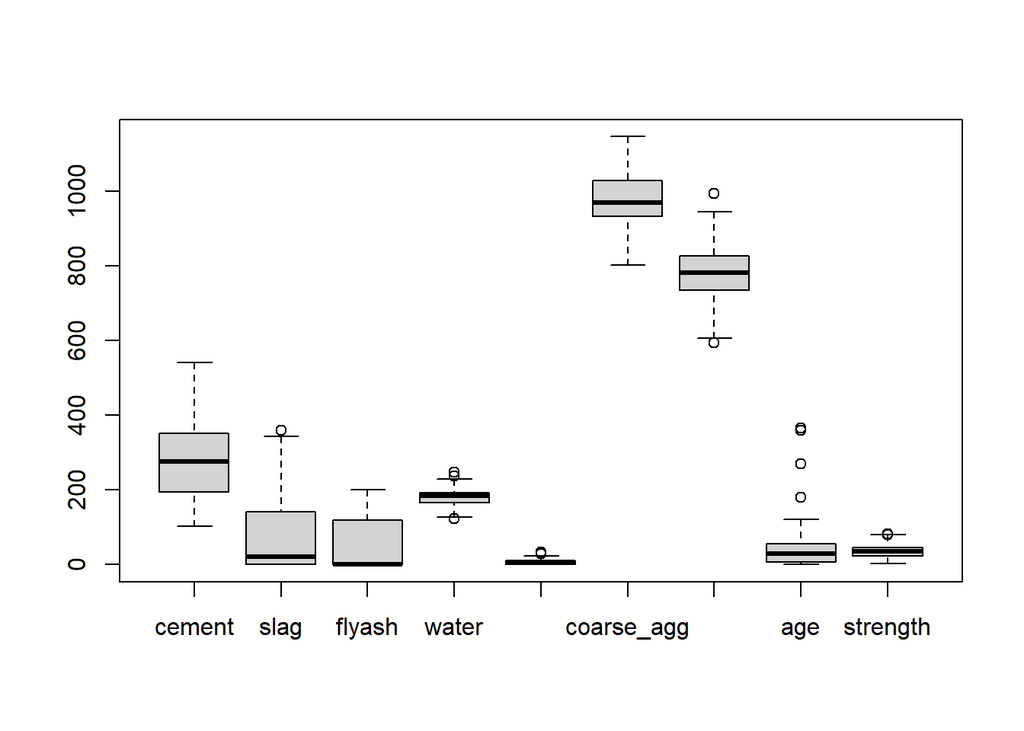

```r
concrete %>% select(-id) %>% boxplot()
```

There are many outliers exist. But because the most harmful outliers is in the target column. We need to inspect more on this.

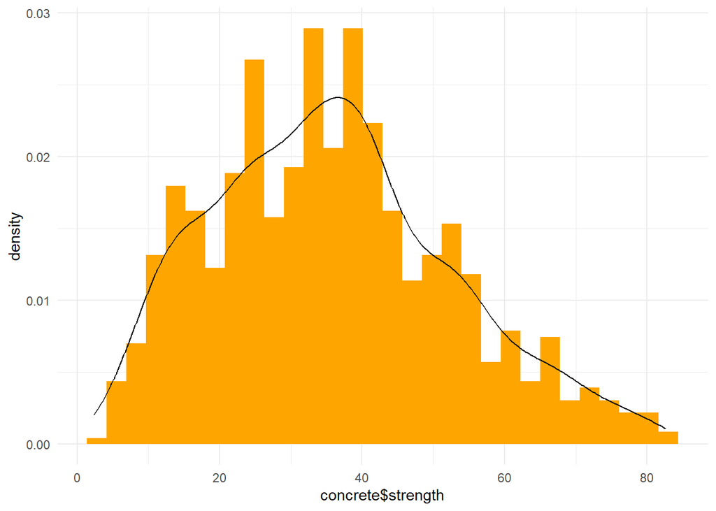

```r
library(ggplot2)
# Building histogram
ggplot(data=concrete, aes(concrete$strength)) +
  geom_histogram(aes(y =after_stat(density)), fill = "orange") +
  geom_density()
```

From the graph above, we can see that column ‘strength’ is right-skewed. From the boxplot we can also see the outliers on around maximum value.

### Removing Outliers

```r
Q1 <- quantile(concrete$strength, .25)
Q3 <- quantile(concrete$strength, .75)
IQR <- IQR(concrete$strength)
```

```r
no_outliers <- subset(concrete, concrete$strength > (Q1 - 1.5*IQR) & concrete$strength < (Q3 + 1.5*IQR))
dim(no_outliers)
```

```
## [1] 820  10
```

```r
dim(concrete)
```

```
## [1] 825  10
```

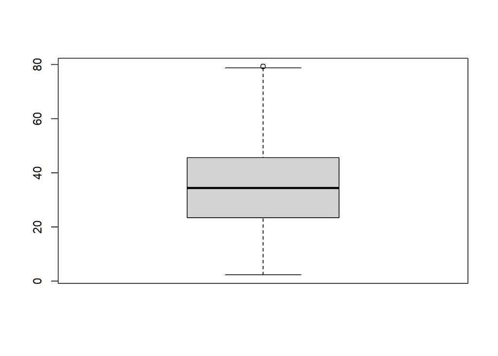

```r
no_outliers$strength %>% boxplot()
```

### Split Data

```r
set.seed(123)
df_row <- nrow(no_outliers)

index <- sample(df_row, 0.8*df_row)

no_outliers <- no_outliers %>% select(-id)

data_train.no <- no_outliers[ index, ]
data_test.no <- no_outliers[ -index, ]

head(data_train.no)
```

|  | cement | slag | flyash | water | super_plast | coarse_agg | fine_agg | age | strength |
| --- | --- | --- | --- | --- | --- | --- | --- | --- | --- |
| 420 | 284.0 | 15.0 | 141.0 | 179.0 | 5.5 | 842.0 | 801.0 | 28 | 43.73 |
| 468 | 339.2 | 0.0 | 0.0 | 185.7 | 0.0 | 1069.2 | 754.3 | 7 | 21.18 |
| 183 | 166.1 | 0.0 | 163.3 | 176.5 | 4.5 | 1058.6 | 780.1 | 28 | 21.54 |
| 531 | 200.0 | 133.0 | 0.0 | 192.0 | 0.0 | 965.4 | 806.2 | 3 | 11.41 |
| 199 | 213.8 | 98.1 | 24.5 | 181.7 | 6.7 | 1066.0 | 785.5 | 100 | 49.97 |
| 119 | 375.0 | 93.8 | 0.0 | 126.6 | 23.4 | 852.1 | 992.6 | 56 | 60.20 |

### Model lm

```r
model_linear.no <- lm(strength ~ . , data = data_train.no)

summary(model_linear.no)
```

```
##
## Call:
## lm(formula = strength ~ ., data = data_train.no)
##
## Residuals:
##     Min      1Q  Median      3Q     Max
## -30.684  -6.487   0.743   6.690  32.723
##
## Coefficients:
##               Estimate Std. Error t value             Pr(>|t|)
## (Intercept) -14.818206  31.741789  -0.467              0.64077
## cement        0.112368   0.010232  10.982 < 0.0000000000000002 ***
## slag          0.094683   0.012003   7.888   0.0000000000000131 ***
## flyash        0.078497   0.015041   5.219   0.0000002428844334 ***
## water        -0.149187   0.048787  -3.058              0.00232 **
## super_plast   0.325670   0.113915   2.859              0.00439 **
## coarse_agg    0.015190   0.011222   1.354              0.17635
## fine_agg      0.015880   0.012594   1.261              0.20778
## age           0.131321   0.007234  18.154 < 0.0000000000000002 ***
## ---
## Signif. codes:  0 '***' 0.001 '**' 0.01 '*' 0.05 '.' 0.1 ' ' 1
##
## Residual standard error: 9.951 on 647 degrees of freedom
## Multiple R-squared:  0.6249, Adjusted R-squared:  0.6203
## F-statistic: 134.8 on 8 and 647 DF,  p-value: < 0.00000000000000022
```

```r
model_step.no <- step(model_linear.no, direction = "both", trace = 0)

summary(model_step.no)
```

```
##
## Call:
## lm(formula = strength ~ cement + slag + flyash + water + super_plast +
##     age, data = data_train.no)
##
## Residuals:
##     Min      1Q  Median      3Q     Max
## -31.107  -6.492   0.829   6.800  32.585
##
## Coefficients:
##              Estimate Std. Error t value             Pr(>|t|)
## (Intercept) 28.007995   5.082965   5.510   0.0000000517422528 ***
## cement       0.100617   0.005101  19.724 < 0.0000000000000002 ***
## slag         0.080907   0.006073  13.322 < 0.0000000000000002 ***
## flyash       0.062995   0.009237   6.820   0.0000000000209316 ***
## water       -0.205931   0.025776  -7.989   0.0000000000000062 ***
## super_plast  0.277754   0.103376   2.687               0.0074 **
## age          0.131042   0.007219  18.153 < 0.0000000000000002 ***
## ---
## Signif. codes:  0 '***' 0.001 '**' 0.01 '*' 0.05 '.' 0.1 ' ' 1
##
## Residual standard error: 9.95 on 649 degrees of freedom
## Multiple R-squared:  0.6239, Adjusted R-squared:  0.6204
## F-statistic: 179.4 on 6 and 649 DF,  p-value: < 0.00000000000000022
```

This model has a slight better R-squared value than the model that’s still having outliers.

Test

```r
pred_test <- predict(model_step.no, data_test.no, type = "response")

eval_recap(truth = data_test.no$strength,
           estimate = pred_test)
```

| RMSE | MAE | R-Square | MSE |
| --- | --- | --- | --- |
| 11.65315 | 9.290359 | 0.5594466 | 3.413671 |

### Model Random Forest + Parameter Tunning

The tunning that we can do are: - improve the ntree - include importance parameter - improve by giving mtry parameter

```r
set.seed(123)
model_rf_no <- randomForest(x = data_train.no %>% select(-strength),
                         y = data_train.no$strength,
                         ntree = 1000,
                         importance = T,
                         mtry = 4)


# Test
pred_test <- predict(model_rf_no, data_test.no, type = "response")

eval_recap(truth = data_test.no$strength,
           estimate = pred_test)
```

| RMSE | MAE | R-Square | MSE |
| --- | --- | --- | --- |
| 5.230991 | 3.734622 | 0.9171555 | 2.287136 |

By doing a better data prepocess (by removing outliers) and tunning the parameter, this model has a better performance. We can see that it has MAE 3.73 and R-Squared 0.917.

### Support Vector Regresssion + Parameter Tunning

```r
model_svr_no <- svm(strength ~ .,
                    data = data_train.no,
                    cost = 10)

# Test
pred_test <- predict(model_svr_no, data_test.no)

eval_recap(truth = data_test.no$strength,
           estimate = pred_test)
```

| RMSE | MAE | R-Square | MSE |
| --- | --- | --- | --- |
| 5.260396 | 3.802074 | 0.907975 | 2.293555 |

This model also has a better performance than the SVR model without improvement in data preprocess and parameter tunning. This model has a slight lower performance than the Random Forest model.

# Model Interpretation

For the Random Forest model, we can find the importance of the variables. We can do it by using $importance. The importances are calculated using the Gini index.

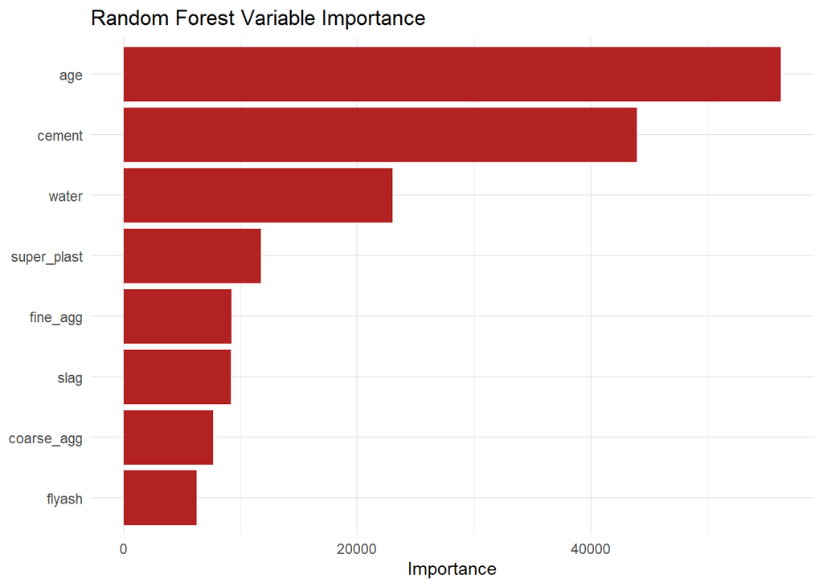

```r
model_rf_no$importance %>%
  as.data.frame() %>%
  arrange(-IncNodePurity) %>%
  rownames_to_column("variable") %>%
  head(10) %>%
  ggplot(aes(IncNodePurity,
             reorder(variable, IncNodePurity))
         ) +
  geom_col(fill = "firebrick") +
  labs(x = "Importance",
       y = NULL,
       title = "Random Forest Variable Importance")
```

From the graph above, we can see the importance scores on every predictor. Age has the biggest importance score. The importance scores does help to understand the significant of a predictor. However, it doesn’t give information about average direction that a variable affects on target value. We also can’t know specifically the influence of each factors for a single observation (no local-fidelity). Thus, we need a better method to interpret the model. LIME is a good method to do it.

## LIME - Explainer

Explainer will be used as foundation to interpret the blacbox model.

```r
set.seed(123)
explainer <- lime(x = data_train.no %>% select(-strength),
                  model = model_rf_no)
```

## LIME - Explaination

The explaination will uncover the explanation of specific observation we need. In this part we will see the explanation on 4 fist row (observation).

```r
# Select only the first 4 observations
selected_data <- data_test.no %>%
  #select(-id) %>%
  select(-strength) %>%
  slice(1:4)

# Explain the model
set.seed(123)
explanation <- explain(x = selected_data,
                       explainer = explainer,
                       feature_select = "auto", # Method of feature selection for lime
                       n_features = 8 # Number of features to explain the model
                       )
```

```
## Error: The class of model must have a model_type method. See ?model_type to get an overview of models supported out of the box
```

```r
class(model_rf)
```

```
## [1] "randomForest"
```

```r
model_type.randomForest <- function(x){
  return("regression") # for regression problem
}
```

```r
predict_model.randomForest <- function(x, newdata, type = "response") {

    # return prediction value
    predict(x, newdata) %>% as.data.frame()

}
```

This part below will give the plot of explanation for 4 first observation. The “n_fearures” used to decide how many predictor will be showed in explanation. It will chose first “n” most significant predictor role to the target. In this part we will see the role of all 8 predictors so we’ll set n_feature = 8.

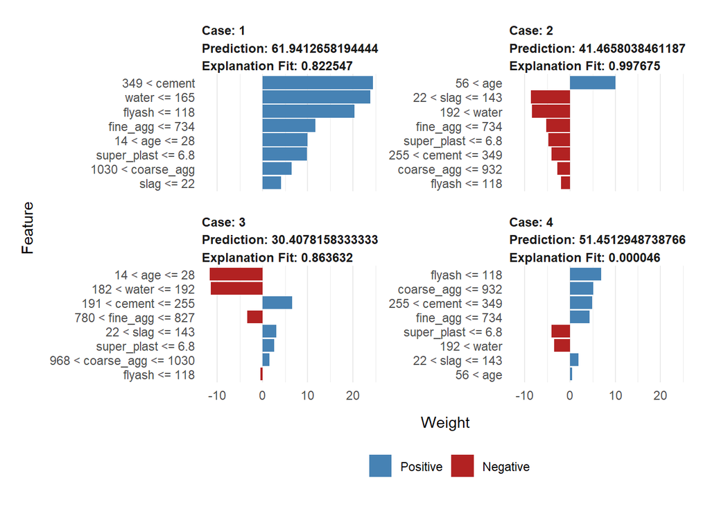

```r
set.seed(123)
explanation <- explain(x = selected_data,
                       explainer = explainer,
                       dist_fun = "euclidean",
                       kernel_width = 0.2,
                       n_features = 8, # Number of features to explain the model
                       feature_select = "auto", # Method of feature selection for lime
                       )

plot_features(explanation)
```

Real value:

```r
head(data_test.no$strength,4)
```

```
## [1] 61.89 41.05 28.02 52.12
```

## LIME SVR

```r
set.seed(123)
explainer <- lime(x = data_train.no %>% select(-strength),
                  model = model_svr_no)
```

```r
class(model_svr)
```

```
## [1] "svm.formula" "svm"
```

```r
model_type.svm <- function(x){
  return("regression") # for regression problem
}

predict_model.svm <- function(x, newdata, type = "response") {

    # return prediction value
    predict(x, newdata) %>% as.data.frame()

}
```

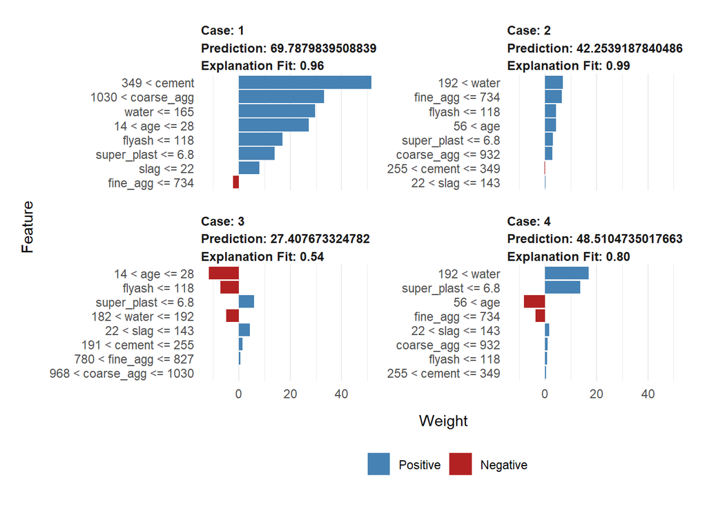

```r
set.seed(123)
explanation <- explain(x = selected_data,
                       explainer = explainer,
                       dist_fun = "manhattan",
                       kernel_width = 0.4,
                       n_features =  8,# Number of features to explain the model
                       feature_select = "auto", # Method of feature selection for lime
                       )

plot_features(explanation)
```

Real value:

```r
head(data_test.no$strength,4)
```

```
## [1] 61.89 41.05 28.02 52.12
```

# Conclusion

From this research we can conclude: - The goal to make a model that can predict the strength value of a concrete based on its material is achieved. This is because the model has a good performance (MAE and R-squared passed the threshold) - The models that passed the threshold are Random Forest Regression Model and Support Vector Regression Model. Random Forest has the highest score. - The method can be implemented in many business scope such as price predictions.

# Addition: try to normalize data

I’ve tried to scale (normalze) the data, but because it didn’t bring a better model I decided not to use it. Here are the results:

```r
normalize <- function(x){
  return((x-min(x))/(max(x)-min(x)))
}
```

```r
concrete_noid <- concrete %>%
  select(-id) %>%
  select(-strength)
concrete_predictor_norm <- as.data.frame(lapply(concrete_noid,normalize))

head(concrete_predictor_norm)
```

|  | cement | slag | flyash | water | super_plast | coarse_agg | fine_agg | age |
| --- | --- | --- | --- | --- | --- | --- | --- | --- |
| 1 | 1.0000000 | 0.0000000 | 0 | 0.3210863 | 0.07763975 | 0.6947674 | 0.2057200 | 0.07417582 |
| 2 | 1.0000000 | 0.0000000 | 0 | 0.3210863 | 0.07763975 | 0.7383721 | 0.2057200 | 0.07417582 |
| 3 | 0.5262557 | 0.3964942 | 0 | 0.8482428 | 0.00000000 | 0.3808140 | 0.0000000 | 0.73901099 |
| 4 | 0.5262557 | 0.3964942 | 0 | 0.8482428 | 0.00000000 | 0.3808140 | 0.0000000 | 1.00000000 |
| 5 | 0.2205479 | 0.3683918 | 0 | 0.5607029 | 0.00000000 | 0.5156977 | 0.5807827 | 0.98626374 |
| 6 | 0.6347032 | 0.2643294 | 0 | 0.8482428 | 0.00000000 | 0.3808140 | 0.0000000 | 1.00000000 |

```r
concrete_norm <- concrete_predictor_norm %>% mutate(strength = concrete$strength)
```

```r
# we need to store the min and max values in case we want to convert back to real values.
minvec <- sapply(concrete_noid,min) #bkn di data train karena nanti max min nya bisa jadi ga imbang di train test
maxvec <- sapply(concrete_noid,max)
```

```r
set.seed(123)
df_row <- nrow(concrete)

index <- sample(df_row, 0.8*df_row)

data_train_norm <- concrete_norm[ index, ]
data_test_norm <- concrete_norm[ -index, ]
```

```r
model_linear_norm <- lm(strength ~ . , data = data_train_norm)

summary(model_linear_norm)
```

```
##
## Call:
## lm(formula = strength ~ ., data = data_train_norm)
##
## Residuals:
##     Min      1Q  Median      3Q     Max
## -30.292  -6.467   0.734   6.892  34.921
##
## Coefficients:
##             Estimate Std. Error t value             Pr(>|t|)
## (Intercept)   -7.327      9.909  -0.739             0.459930
## cement        52.726      4.519  11.667 < 0.0000000000000002 ***
## slag          36.718      4.360   8.421 0.000000000000000238 ***
## flyash        17.257      3.111   5.548 0.000000042176699685 ***
## water        -14.336      6.042  -2.373             0.017942 *
## super_plast   12.387      3.659   3.385             0.000754 ***
## coarse_agg     8.360      3.868   2.161             0.031044 *
## fine_agg       9.363      5.143   1.820             0.069174 .
## age           45.340      2.561  17.706 < 0.0000000000000002 ***
## ---
## Signif. codes:  0 '***' 0.001 '**' 0.01 '*' 0.05 '.' 0.1 ' ' 1
##
## Residual standard error: 10.23 on 651 degrees of freedom
## Multiple R-squared:  0.615,  Adjusted R-squared:  0.6102
## F-statistic:   130 on 8 and 651 DF,  p-value: < 0.00000000000000022
```

```r
model_step1 <- step(model_linear_norm, direction = "both", trace = 0)

summary(model_step1)
```

```
##
## Call:
## lm(formula = strength ~ cement + slag + flyash + water + super_plast +
##     coarse_agg + fine_agg + age, data = data_train_norm)
##
## Residuals:
##     Min      1Q  Median      3Q     Max
## -30.292  -6.467   0.734   6.892  34.921
##
## Coefficients:
##             Estimate Std. Error t value             Pr(>|t|)
## (Intercept)   -7.327      9.909  -0.739             0.459930
## cement        52.726      4.519  11.667 < 0.0000000000000002 ***
## slag          36.718      4.360   8.421 0.000000000000000238 ***
## flyash        17.257      3.111   5.548 0.000000042176699685 ***
## water        -14.336      6.042  -2.373             0.017942 *
## super_plast   12.387      3.659   3.385             0.000754 ***
## coarse_agg     8.360      3.868   2.161             0.031044 *
## fine_agg       9.363      5.143   1.820             0.069174 .
## age           45.340      2.561  17.706 < 0.0000000000000002 ***
## ---
## Signif. codes:  0 '***' 0.001 '**' 0.01 '*' 0.05 '.' 0.1 ' ' 1
##
## Residual standard error: 10.23 on 651 degrees of freedom
## Multiple R-squared:  0.615,  Adjusted R-squared:  0.6102
## F-statistic:   130 on 8 and 651 DF,  p-value: < 0.00000000000000022
```

```r
set.seed(123)
model_rf <- randomForest(x = data_train_norm %>% select(-strength),
                         y = data_train_norm$strength,
                         ntree = 1000)

model_rf
```

```
##
## Call:
##  randomForest(x = data_train_norm %>% select(-strength), y = data_train_norm$strength,      ntree = 1000)
##                Type of random forest: regression
##                      Number of trees: 1000
## No. of variables tried at each split: 2
##
##           Mean of squared residuals: 35.26126
##                     % Var explained: 86.84
```

```r
pred_test <- predict(model_rf, data_test_norm, type = "response")

eval_recap(truth = data_test_norm$strength,
           estimate = pred_test)
```

| RMSE | MAE | R-Square | MSE |
| --- | --- | --- | --- |
| 6.15579 | 4.701605 | 0.9071986 | 2.481087 |

The result is not even better than the model without normalization on data.